# Classification tree

**Method**

A classification tree uses different predictors to sequentially sort cases into “purer” categories of outcomes, with the end goal of knowing which sequence and/or cutoff values of predictors leads to having an outcome of A or B. This is a different technique compared to logistic regression, which uses a weighted combination of predictors to calculate a probability of an outcome being A or B. One advantage of classification trees over logistic regression is that the results are easier to interpret and more practically useful. There is a trade-off between the simplicity of the tree and its accuracy; selecting a stricter criterion (complexity parameter) so that fewer branches are allowed to grow makes the results easier to interpret, but tends to decrease the classification accuracy of the tree.

One advantage of classification trees is that they can still work with missing data, whereas techniques such as logistic regression require that all variables be complete. To handle a dataset in which some observations are missing data, the algorithm first chooses a splitting rule (e.g. HHIE < 19 and HHIE ≥ 19) based only on observations with complete data for that variable. Once the splitting rule has been established, the algorithm then examines all other variables (age, PTA, …) and ranks them on how well they split the data just like the established rule. These will be “surrogate” variables for the observations that are missing data for the established rule. Surrogates can be ranked on how much they resemble the established variable in sorting observations with complete data. For example, if PTA is the top-ranked surrogate for HHIE, then observations with missing HHIE data but present PTA data will be sorted using PTA. If the observation is also missing PTA in addition to missing HHIE, then the next best surrogate will be used to sort it (e.g. age), and so on. In the worst-case scenario, if an observation is missing all predictor variables, it will simply be sorted into the class with the majority of cases at that particular split.

All participants included in this analysis had PTA > 25 in the better ear. The first model was constructed for the subset of participants with complete data across the 28 predictors of interest (n=753). A second model was constructed for a larger dataset in which some of the 28 predictors had [missing data](https://huiwen-goy.github.io/connect1-stigma/Connect1_Stigma_describe_imputation.html) (n=1396). A third model was constructed with missing data, but excluding participants who had more than 2 predictors missing (n=1196 remaining). A fourth model was constructed for a dataset in which all missing data had been imputed (n=1396). For all models, I added case weights so that there was an “equivalent” number of ‘Yes’ and ‘No’ outcomes, so that the model would not be biased towards ‘No’ cases.

### Analysis using complete cases only (n=753)

**Results**

[Full tree, 41 splits](https://huiwen-goy.github.io/connect1-stigma/tree_n753_cp0.pdf)

[Tree with depth 2](https://huiwen-goy.github.io/connect1-stigma/tree_n753_depth2.pdf)

[Tree with depth 3](https://huiwen-goy.github.io/connect1-stigma/tree_n753_depth3.pdf)

[Tree with depth 4](https://huiwen-goy.github.io/connect1-stigma/tree_n753_depth4.pdf)

### Analysis including all cases with missing predictors (n=1396)

**Results**

[Full tree, 74 splits](https://huiwen-goy.github.io/connect1-stigma/tree_n1396miss_cp0.pdf)

[Tree with depth 2](https://huiwen-goy.github.io/connect1-stigma/tree_n1396miss_depth2.pdf)

[Tree with depth 3](https://huiwen-goy.github.io/connect1-stigma/tree_n1396miss_depth3.pdf)

[Tree with depth 4](https://huiwen-goy.github.io/connect1-stigma/tree_n1396miss_depth4.pdf)

### Analysis dropping cases with 3 or more missing predictors (n=1196)

**Results**

The vast majority of participants had little or no missing data in the predictor variables; those with 3 or more missing predictors were considered outliers in a boxplot. It was possible that cases with relatively large amounts of missing data affected the model, so I performed a quick check by dropping 200 cases where there were 3 or more missing predictors.

[Full tree, 73 splits](https://huiwen-goy.github.io/connect1-stigma/tree_n1196_cp0.pdf)

[Tree with depth 2](https://huiwen-goy.github.io/connect1-stigma/tree_n1196_depth2.pdf)

[Tree with depth 3](https://huiwen-goy.github.io/connect1-stigma/tree_n1196_depth3.pdf)

[Tree with depth 4](https://huiwen-goy.github.io/connect1-stigma/tree_n1196_depth4.pdf)

### Analysis using imputed data (n=1396)

**Results**

[Full tree, 82 splits](https://huiwen-goy.github.io/connect1-stigma/tree_n1396imp_cp0.pdf)

[Tree with depth 2](https://huiwen-goy.github.io/connect1-stigma/tree_n1396imp_depth2.pdf)

[Tree with depth 3](https://huiwen-goy.github.io/connect1-stigma/tree_n1396imp_depth3.pdf)

[Tree with depth 4](https://huiwen-goy.github.io/connect1-stigma/tree_n1396imp_depth4.pdf)

### Conclusions

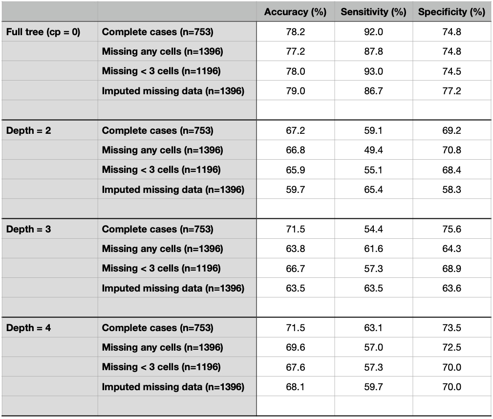

In general, the classification tree models were in the same range of performance as or slightly better than the logistic regression models (where none of the metrics exceeded the 60s), with the advantage of more interpretable results.